# @MPRA package vignette

Dandi Qiao

2020-07-21

#1 Introduction The analysis toolset for MPRA data (@MPRA) includes functions for simulating and analyzing MPRA data, and for power calculations of MPRA experiments. This tutorial briefly introduces the functions provided by the @MPRA package, using the example data included in the package.

We can load the library using:

```r
library(atMPRA)
```

We can do a quick power calculation:

```r
nsim = 10
ntag = 10

result = getPower(nsim = nsim, ntag = ntag, nrepIn = 3, nrepOut = 3,
    slope = c(rep(1, ntag * nsim), rep(2, ntag * nsim)), method = c("MW",
        "mpra_lm"), scenario = "fixTotalDepth")
```

```
## [1] 0.6
```

```r
result$Power
```

```
## [1] 0.6
```

#2 Data available in the package

The estimated distributional parameters of the MPRA data (GSE70531 in GEO database) was obtained using the `estimateMPRA` function in this package. The basic parameters include \ `inputProp`: The proportion of counts per tag among all tags in the library\ `transEff`: The distribution of transfection efficiencies (normalized RNA/DNA ratio) across tags\ `dispFunc_input`: The dispersion function of the input tag counts across replicates as a function of the mean \ `dispFunc_output`: The dispersion function of the output tag counts across replicates as a function of the mean\ \

We assume that the tag counts across replicates follow a Negative Binomial distribution with mean $\mu$ and dispersion $\sigma^2$. Then the variance is $\mu + \sigma^2\mu^2$.

However, it is observed that the dispersion parameter is not constant in RNA-Seq data. In DESeq2, it was assumed that:
$$log(\sigma^2) \sim N(log(a+b/\mu), \sigma_d^2)$$
We will use the dispersion function estimated by DESeq2 to generate count data here.

The estimation parameters for GSE70531 was done using the `estimateMPRA` function which used DESeq2 package. This distribution will be the default distribution for simulating MPRA data in this package if not specified otherwise. The data is loaded with the package automatically.

```r
GSE70531_params
```

```
## $dispFunc_input
## function (means)
## exp(predict(fit, data.frame(logMeans = log(means))))
## <bytecode: 0x7fccfa160130>
## <environment: 0x7fccfc0b0ea8>
## attr(,"fitType")
## [1] "local"
## attr(,"varLogDispEsts")
## [1] 0.4812829
## attr(,"dispPriorVar")
## [1] 0.25
##
## $dispFunc_output
## function (q)
## coefs[1] + coefs[2]/q
## <bytecode: 0x7fcce7d0aa88>
## <environment: 0x7fccfa160478>
## attr(,"coefficients")
## asymptDisp  extraPois
##  0.5183263 12.7233435
## attr(,"fitType")
## [1] "parametric"
## attr(,"varLogDispEsts")
## [1] 0.8172103
## attr(,"dispPriorVar")
## [1] 0.3268525
##
## $inputProp
## function (v)
## .approxfun(x, y, v, method, yleft, yright, f)
## <bytecode: 0x7fcce7d08430>
## <environment: 0x7fcce7d0b428>
##
## $transEff
## function (v)
## .approxfun(x, y, v, method, yleft, yright, f)
## <bytecode: 0x7fcce7d09cb0>
## <environment: 0x7fcce7d08e78>
##
## $sizeFactor_input
## K562_minP_DNA1 K562_minP_DNA2
##      1.2060454      0.8291562
##
## $sizeFactor_output
## K562_CTRL_minP_RNA1 K562_CTRL_minP_RNA2 K562_CTRL_minP_RNA3 K562_CTRL_minP_RNA4
##           0.6613516           0.4404059           1.4904598           1.2337356
## K562_CTRL_minP_RNA5 K562_CTRL_minP_RNA6
##           1.8488591           1.3372992
```

The input proportions are usually very skewed due to cloning and PCR.

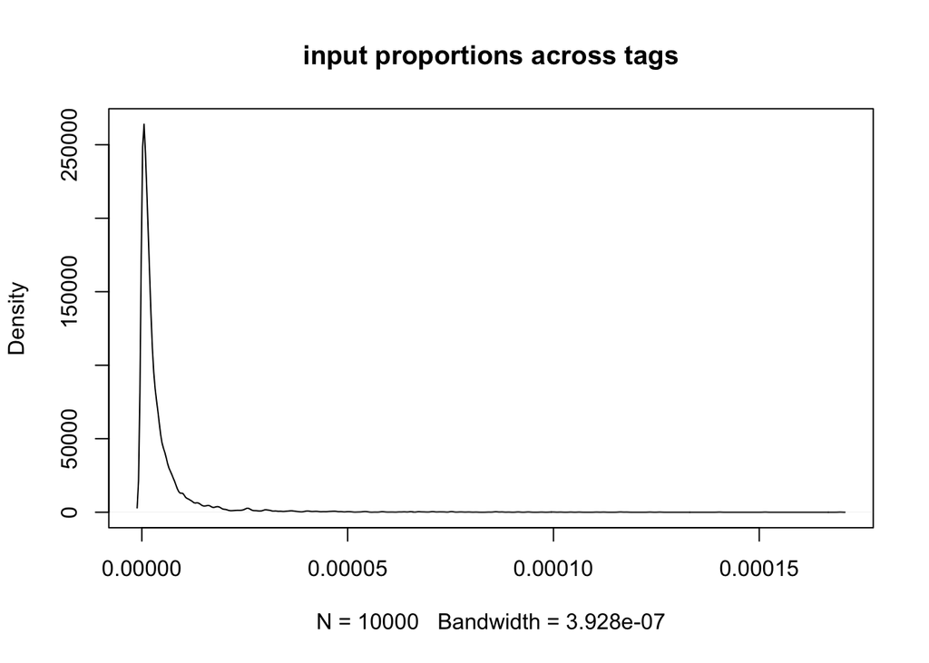

```r
plot(density(GSE70531_params[[3]](runif(10000))), main="input proportions across tags")
```

The transfection efficiency distribution for GSE70531 looks like this:

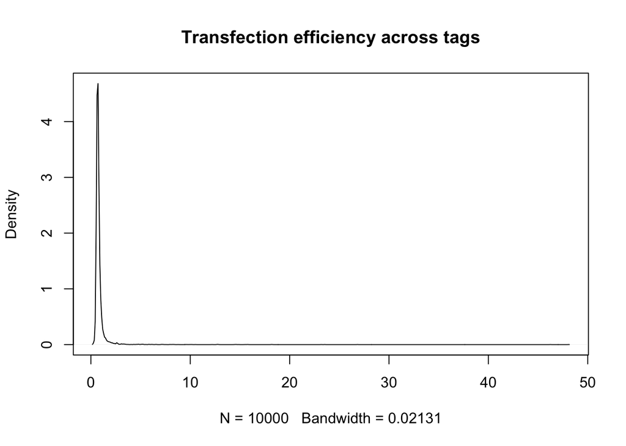

```r
plot(density(GSE70531_params[[4]](runif(10000))), main="Transfection efficiency across tags")
```

#3 Functions

## 3.1 Simulating MPRA data

There are multiple ways to simulate MPRA data in this package:

1. Simulating MPRA data using default distribution.
2. Simulating MPRA data using estimated distributions from observed data
3. Simulating MPRA data by specifying parameters in the model.

The parameters for simulating a MPRA dataset includes:

1. number of SNPs in the data (`nsim`)
2. number of tags per SNP (`ntag`)
3. number of replicates in the input and output (`nrepIn`, `nrepOut`)
4. RNA/DNA ratio for all tags (`slope`)
5. Total depth for one replicate (`fixTotalD`) or mean depth per tag (`fixMeanD`)

### 3.1.1 Simulating MPRA data using estimated distributions from observed data

```r
totalDepth = 2e+05

ntag = 10

nsim = 10

nrepIn = 5

nrepOut = 5

inputProp = GSE70531_params[[3]](runif(ntag * nsim * 2))

slopel = GSE70531_params[[4]](runif(nsim * 2))

inputDispFunc = GSE70531_params[[1]]

outputDispFunc = GSE70531_params[[2]]

slope = rep(slopel, each = ntag)

datt = sim_fixDepth(inputProp, ntag, nsim, nrepIn, nrepOut, slope,
    inputDispFunc = inputDispFunc, outputDispFunc = outputDispFunc,
    sampleDepth = totalDepth)

datt[1:10, ]
```

```
##    allele simN input_rep1 input_rep2 input_rep3 input_rep4 input_rep5
## 1     Ref    1        260        256        231        255        287
## 2     Ref    1          1         10          2          4          4
## 3     Ref    1       1391       1278       1142       1186       1265
## 4     Ref    1        205        186        219        187        206
## 5     Ref    1       8462       7516       7644       8347       8155
## 6     Ref    1         88        100         84        103         88
## 7     Ref    1         27         35         17         22         22
## 8     Ref    1         11          5          4          7          3
## 9     Ref    1        984        733        869       1014        961
## 10    Ref    1          3         17          4          4          2
##    output_rep1 output_rep2 output_rep3 output_rep4 output_rep5
## 1          151         152         161          42         259
## 2            3           6           2           0           7
## 3          389         573         520         912         263
## 4          159         261         344          67         441
## 5         1876        7831        4976       32775        2339
## 6           71          61           6          25          36
## 7           66           1          58          93          33
## 8            0          61           0           0           0
## 9         1464         670         729         253         384
## 10           0           2           9           0          17
```

If we would like to simulate data based on an observed MPRA dataset, we can estimate the parameters using the function `estimateMPRA`.

```r
rnaCol=8

new_params=estimateMPRA(datt, nrepIn, rnaCol, nrepOut, nsim, ntag)

new_params
```

```
## $dispFunc_input
## function (q)
## coefs[1] + coefs[2]/q
## <bytecode: 0x7fcce8f066f8>
## <environment: 0x7fcce8f060a0>
## attr(,"coefficients")
##   asymptDisp    extraPois
## 0.0009010884 3.1335274766
## attr(,"fitType")
## [1] "parametric"
## attr(,"varLogDispEsts")
## [1] 1.080094
## attr(,"dispPriorVar")
## [1] 0.4351599
##
## $dispFunc_output
## function (q)
## coefs[1] + coefs[2]/q
## <bytecode: 0x7fcce8f066f8>
## <environment: 0x7fccd6ebcdd8>
## attr(,"coefficients")
## asymptDisp  extraPois
##  0.6251106 10.1772434
## attr(,"fitType")
## [1] "parametric"
## attr(,"varLogDispEsts")
## [1] 0.9503926
## attr(,"dispPriorVar")
## [1] 0.3054585
##
## $inputProp
## function (v)
## .approxfun(x, y, v, method, yleft, yright, f, na.rm)
## <bytecode: 0x7fcce3328120>
## <environment: 0x7fcce3317898>
##
## $transEff
## function (v)
## .approxfun(x, y, v, method, yleft, yright, f, na.rm)
## <bytecode: 0x7fcce3328120>
## <environment: 0x7fcce312acc8>
##
## $sizeFactor_input
## input_rep1 input_rep2 input_rep3 input_rep4 input_rep5
##  1.0094711  0.9957707  1.0058437  0.9923409  0.9984510
##
## $sizeFactor_output
## output_rep1 output_rep2 output_rep3 output_rep4 output_rep5
##    1.110113    1.146678    1.035088    1.027471    1.042535
```

Then we can simulate new MPRA data using these parameters:

```r
datt = sim_fixDepth(inputProp = new_params[[3]](runif(ntag * nsim * 2)),
    ntag, nsim, nrepIn, nrepOut, slope, inputDispFunc = new_params[[1]],
    outputDispFunc = new_params[[2]], sampleDepth = totalDepth)

datt[1:10, ]
```

```
##    allele simN input_rep1 input_rep2 input_rep3 input_rep4 input_rep5
## 1     Ref    1       1815       1689       1822       1836       1976
## 2     Ref    1        295        261        295        287        317
## 3     Ref    1        742        779        811        780        644
## 4     Ref    1        282        213        258        264        220
## 5     Ref    1        681        687        701        610        583
## 6     Ref    1          7         19         20         28         15
## 7     Ref    1         78         60        139         90         55
## 8     Ref    1          2          3          4         15          8
## 9     Ref    1        769        836        911        912        824
## 10    Ref    1         77         87         85        121         78
##    output_rep1 output_rep2 output_rep3 output_rep4 output_rep5
## 1         1065         247        1278        2517        2382
## 2           35          61         260         354         375
## 3          114         230         119        1485         244
## 4           52         148         135          68         207
## 5          231         177         471         207         340
## 6            5          19          22           7          13
## 7            3          21           2          27           1
## 8            0          26           0           2           1
## 9          375         344         538         512         135
## 10          15           7          16           0         310
```

### 3.1.2 Simulating MPRA data by specifying parameters in the model.

We can also simulate MPRA data by specifying parameters. For example, we may want to specify different mean input counts across tags for allele A and allele B. We can check if methods are biased by the allelic imbalance in the input distribution later using this simulated data.

```r
inputDist = GSE70531_params[[3]](runif(nsim * ntag * 2))

datt = sim_fixInputMean(mean_A = 10, mean_B = 100, ntag = ntag, nsim = nsim,
    nrepIn = nrepIn, nrepOut = nrepOut, slope = slope, inputDist = inputDist,
    inputDispFunc = inputDispFunc, outputDispFunc = outputDispFunc)
datt[c(1:5, 101:105), ]
```

```
##     allele simN input_rep1 input_rep2 input_rep3 input_rep4 input_rep5
## 1      Ref    1         21         11         23         35          6
## 2      Ref    1          3          0          0          0          0
## 3      Ref    1          0          0          9          4          1
## 4      Ref    1          4          0          0          0          0
## 5      Ref    1         22         18         14          9          4
## 101    Mut    1         19         15          6         22         10
## 102    Mut    1        552        642        601        616        617
## 103    Mut    1         82         91        100         52        119
## 104    Mut    1        212        200        182        186        216
## 105    Mut    1         15         17         12          8         32
##     output_rep1 output_rep2 output_rep3 output_rep4 output_rep5
## 1            16          11          17          10          10
## 2             0           0           0           0           0
## 3             0           2           2           0           0
## 4             5           0           0           0           0
## 5             1           6          23           3           2
## 101           0          10          12           3           2
## 102         642         283        1389         458         467
## 103          44          12          33          35          93
## 104          57          55          58           6          87
## 105          30          53           5          10          20
```

Note the distribution of counts are very different between the two alleles `Ref` and `Mut`.

Another way to specify the dispersion function is through `inputDispParam` and `outputDispParam`. These parameters are required if `inputDispFunc` and `outputDispFunc` are not provided. Each of them should give the three parameter estimates ($a, b, \sigma_d^2$) for the dispersion function of the DNA input or RNA output counts across replicates. The three parameters correspond to $a$, $b$, and $\sigma_d^2$, which specify that the dispersion parameter is a lognormal distribution with mean $log(a+b/\mu)$ and sd $\sigma_d^2$, where $\mu$ is the mean of RNA count across the replicates.

```r
datt = sim_fixDepth(inputProp = new_params[[3]](runif(ntag * nsim * 2)),
    ntag, nsim, nrepIn, nrepOut, slope, inputDispParam = c(0, 4.37, 0.25),
    outputDispParam = c(0.54, 12, 0.25), sampleDepth = totalDepth)
### Thesea are default dispersion parameters, if none was specified.
datt[1:10, ]
```

```
##    allele simN input_rep1 input_rep2 input_rep3 input_rep4 input_rep5
## 1     Ref    1         79        139        124        128         96
## 2     Ref    1         34          7         31         28         38
## 3     Ref    1        214        255        171        199        231
## 4     Ref    1         89        182        108        170        154
## 5     Ref    1        828        837        830       1038       1034
## 6     Ref    1        691        758        644        649        722
## 7     Ref    1       1038        896       1139        918       1109
## 8     Ref    1        885       1031       1004        925        810
## 9     Ref    1        814        858        729        716        811
## 10    Ref    1         18         23          6         24         25
##    output_rep1 output_rep2 output_rep3 output_rep4 output_rep5
## 1           29          56         153          19          93
## 2           15           9          22          15           7
## 3            9         133         162         209         188
## 4           94          20         224          53         106
## 5          650         428        1058         603         508
## 6          373          10         569           9        1970
## 7            7         490         534         680         865
## 8          584         201         733         486        1242
## 9          726         212         169         188         439
## 10          20          12           5          13          29
```

## 3.2 Analyze MPRA data

We provide a list of methods to analyze MPRA data. The input MPRA data frame should have `nsim*ntag*2` rows and `2+nrepIn+nrepOut` columns. The first column should be named ‘allele’, and the second column should be named ‘simN’. The ‘allele’ columns should contain only two possible values ‘Ref’ and ‘Mut’ to refer to the two versions of alleles for each SNP.

A list of the methods that are available is here:

| Test | singleReplicate | OptionName |
| --- | --- | --- |
| Mann-Whitney | YES | MW |
| Matching | YES | Matching |
| Adaptive | YES | Adaptive |
| QuASAR-MPRA | YES | QuASAR |
| Fisher’s Exact Test | YES | Fisher |
| T-test | NO | T-test |
| mpralm using mean | NO | mpralm |
| mpralm using sum | NO | mpralm |
| edgeR | NO | edgeR |
| DESeq2 | NO | DESeq2 |

To analyze a formmated MPRA data:

```r
datt[1:10, ]
```

```
##    allele simN input_rep1 input_rep2 input_rep3 input_rep4 input_rep5
## 1     Ref    1         79        139        124        128         96
## 2     Ref    1         34          7         31         28         38
## 3     Ref    1        214        255        171        199        231
## 4     Ref    1         89        182        108        170        154
## 5     Ref    1        828        837        830       1038       1034
## 6     Ref    1        691        758        644        649        722
## 7     Ref    1       1038        896       1139        918       1109
## 8     Ref    1        885       1031       1004        925        810
## 9     Ref    1        814        858        729        716        811
## 10    Ref    1         18         23          6         24         25
##    output_rep1 output_rep2 output_rep3 output_rep4 output_rep5
## 1           29          56         153          19          93
## 2           15           9          22          15           7
## 3            9         133         162         209         188
## 4           94          20         224          53         106
## 5          650         428        1058         603         508
## 6          373          10         569           9        1970
## 7            7         490         534         680         865
## 8          584         201         733         486        1242
## 9          726         212         169         188         439
## 10          20          12           5          13          29
```

```r
results = analyzeMPRA(datt, nrepIn, rnaCol, nrepOut, nsim, ntag, method = c("MW",
    "Adaptive", "QuASAR", "T-test", "mpralm", "DESeq2"), cutoff = 0, cutoffo = 0)
results
```

```
## $MW
##    simN       res_MW
## 1     1 0.1431401416
## 2     2 0.0089306978
## 3     3 0.0354629890
## 4     4 0.1431401416
## 5     5 0.6842105263
## 6     6 0.0752560133
## 7     7 0.0001299011
## 8     8 0.5288488601
## 9     9 0.0010500336
## 10   10 0.9705124597
##
## $Matching
##    simN res_matching
```

[output cut: 128 more lines]

You can remove tags with mean counts less than the cutoffs specified for the input and output.

## 3.3 Power calculation

We can compute power based on simulated MPRA data specified using the options described above. Addition parameters here include the correction method for multiple testing, and the significance level to be used.

```r
nrepIn = 2
nrepOut = 2
slopel = GSE70531_params[[4]](runif(nsim))
slopel = c(slopel, slopel + 1)
slope = rep(slopel, each = ntag)
result2 = getPower(nsim, ntag, nrepIn, nrepOut, slope, scenario = "fixInputDist",
    method = c("MW", "T-test", "mpralm", "edgeR", "DESeq2"),
    fixInput = c(20, 100), inputDist = inputDist, inputDispFunc = inputDispFunc,
    outputDispFunc = outputDispFunc, cutoff = -1, cutoffo = -1)
```

```
##        resMW ttest_paired        ttest  mpralm_mean   mpralm_sum        edgeR
##          0.1          0.0          0.0          0.0          0.1          0.3
##       DESeq2
##          0.4
```

```r
result2$Power
```

```
##        resMW ttest_paired        ttest  mpralm_mean   mpralm_sum        edgeR
##          0.1          0.0          0.0          0.0          0.1          0.3
##       DESeq2
##          0.4
```

```r
result3 = getPower(nsim, ntag, nrepIn, nrepOut, slope = 1, scenario = "fixTotalDepth",
    method = c("MW", "Matching", "Adaptive", "Fisher", "QuASAR", "T-test",
        "mpralm", "edgeR", "DESeq2"), fixTotalD = 2e+05, inputDist = inputDist,
    inputDispFunc = inputDispFunc, outputDispFunc = outputDispFunc, cutoff = -1,
    cutoffo = -1)
```

```
##        resMW  resMatching  resAdaptive       QuASAR fisherPvalue ttest_paired
##          0.0          0.0          0.0          0.0          0.8          0.0
##        ttest  mpralm_mean   mpralm_sum        edgeR       DESeq2
##          0.0          0.0          0.0          0.1          0.2
```

```r
result3$Power
```

```
##        resMW  resMatching  resAdaptive       QuASAR fisherPvalue ttest_paired
##          0.0          0.0          0.0          0.0          0.8          0.0
##        ttest  mpralm_mean   mpralm_sum        edgeR       DESeq2
##          0.0          0.0          0.0          0.1          0.2
```

## 3.4. Other methods included

`calEnrichment`: This function uses hypergeometric tests to compute enrichment in SNPs with significant allelic DNA imbalance among the SNPs with significant allele-specific effect defined by each method.

```r
calEnrichment(results$resultAll)
```

```
## Compute enrichment in allele-imbalanced SNPs among significant results...
```

```
##         method  q m  n k enrichP
## 1        resMW -1 4  6 1       1
## 2  resMatching -1 0 10 1       1
## 3  resAdaptive -1 4  6 1       1
## 4       QuASAR -1 1  9 1       1
## 5 ttest_paired -1 2  8 1       1
## 6        ttest -1 2  8 1       1
## 7  mpralm_mean -1 4  6 1       1
## 8   mpralm_sum -1 2  8 1       1
## 9       DESeq2 -1 3  7 1       1
```